# Mongolia Trust Index

Summary

# Sampling

## Coverage

The sampling approach used was a non-probability sampling, that at least in part used contact information of an existing database of people associated and acquainted with the Mongolia Red Cross Society. The sample is skewed towards the rural population, with 58% of the sample being classified as rural, while according to World Bank data that rural population is closer to 30%.

It is important to note that this non-probability design does not allow for inferences to be made about the general population in Mongolia. Therefore, all the data should be regarded as indicative, and it is strongly advised against presenting this data as representative of the entire country of Mongolia, as the convenience sampling approach taken does not allow for drawing generalizations for the population in Mongolia.

However, a post-stratification technique can be employed to ensure that the weighted sample corresponds to some features of the population more closely. Therefore, a initial analysis focuses on a few demographic parameters of our sample and compares them to the overall population in the country.

[interactive chart not shown]

## Gender and Age

Compared to the overall Mongolian population, in the sample women are over-represented, while younger people, especially men are under-represented.

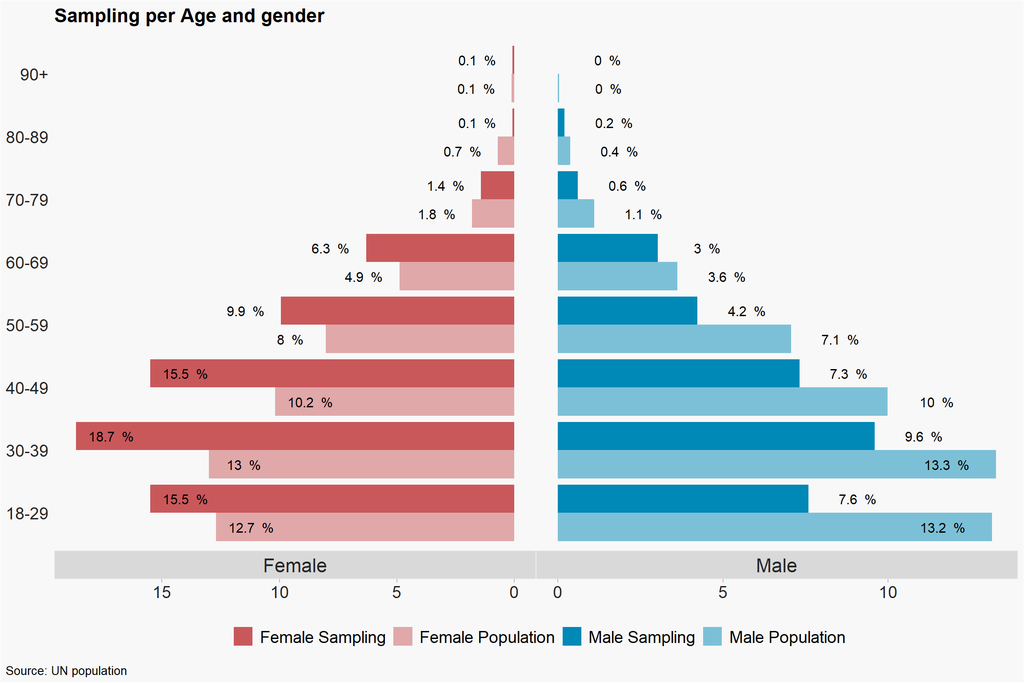

## Education

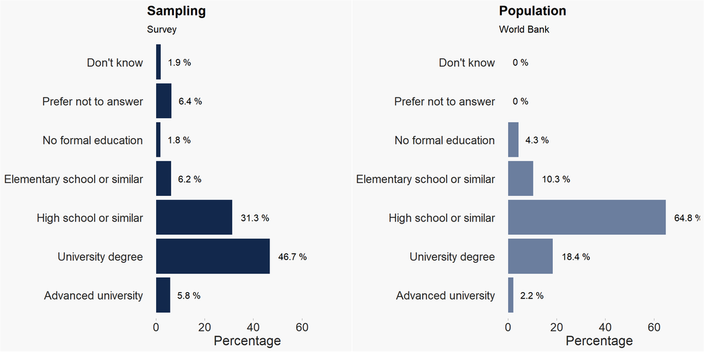

## Employment

While it was difficult to source matching data on work employment, available data sourced from the World Bank suggests that people with employment in agriculture are underrepresented in the sample, which matches the larger share of people with higher education in the sample.

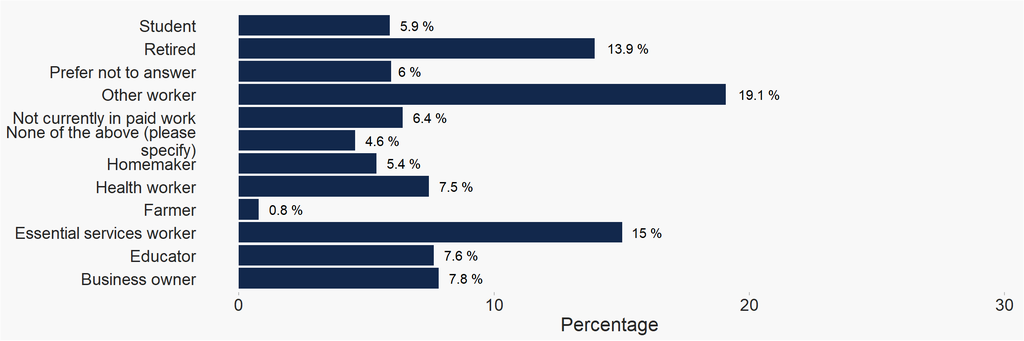

## NS relationship

Since the sample is skewed towards those who have a history/relationship with the Mongolian Red Cross Society, it is to be expected that a fairly large share of the sample has donated to the Mongolian Red Cross Society, requested and received support. We indeed see that in our sample with 40% of the people having volunteered or made a donation, and more than 25% having received support.

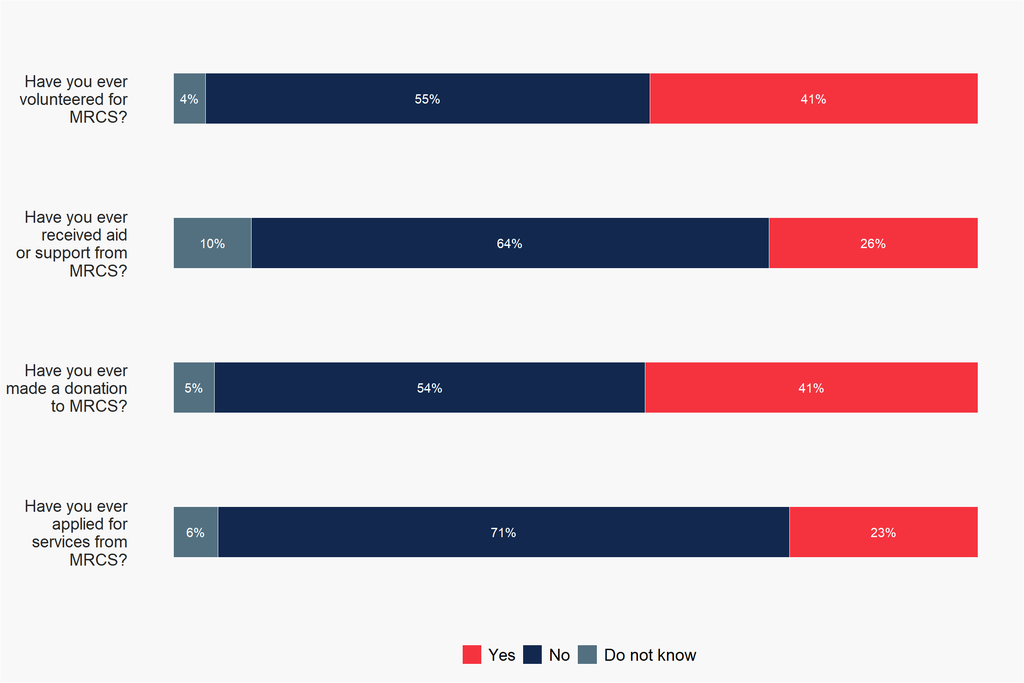

# Results

*Distribution of mean scores for overall competency and values per demographic questions*

## Score distribution

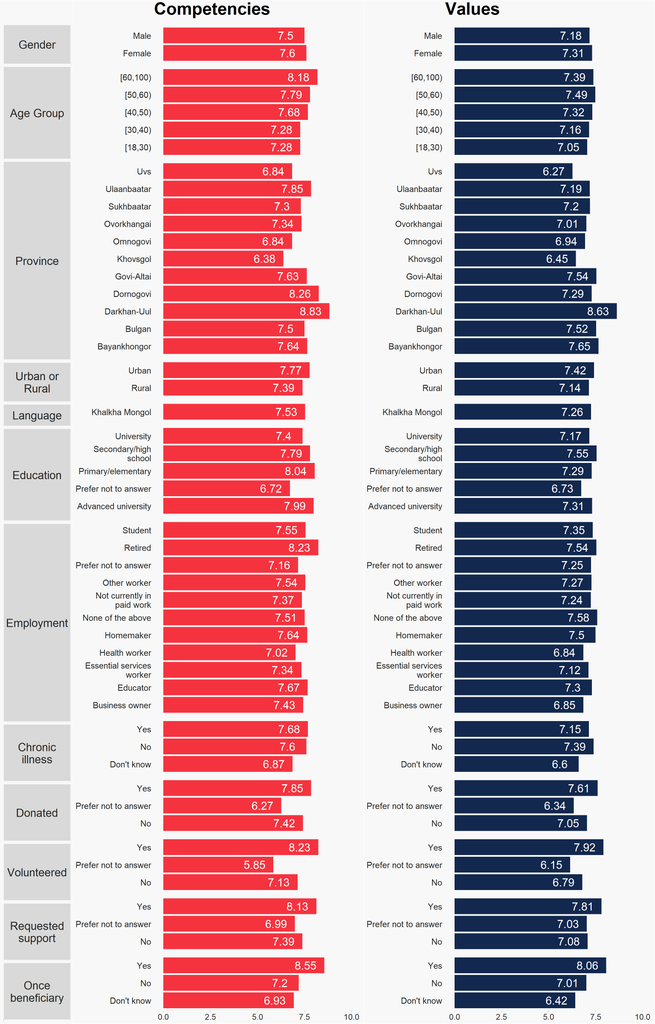

## Weighting

To at least partly address the deviation of demographic parameters from the overall population, we have utilized a technique called raking. The raking process adjusts the results based on several variables to ensure that our sample reflects the distribution of these variables in the overall population. Here are the variables we considered for raking:

- Age groups and gender: We used UN data to determine the proportions of different age groups and gender in the population.
- Education: We used World Bank data on education of the general population in Mongolia

Additionally, we can make assumptions for the upper bounds of volunteer and aid recipient percentages since no specific data was available. We estimated these rates to be 10% of the population to just see the impact of the large share of volunteers and beneficiaries in the sample. These rates of 10% are just estimates and we will not use this raking scenario for further analysis. It can, however, help to to understand better the impact of the biased sample.

Using an appropriate package in R to conduct the raking, we obtained the following results:

- Raking scenario 1: Raked by age groups, gender, education.
- Raking scenario 2: Scenario 1 with additional raking by the percentage of respondents who volunteered (assuming 10% of the population volunteered).

The results indicate that the un-weighted results provide the most positive ratings across the questions. If we cap the percentage of volunteers and beneficiaries, results are lower compared to raking using just general demographic values (scenario 1).

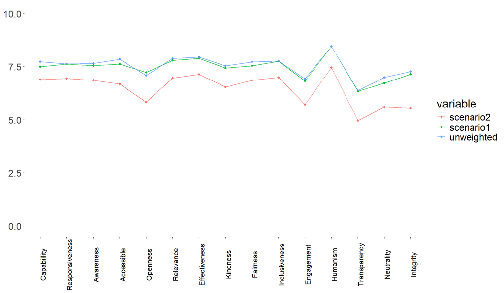

## Weighted Results

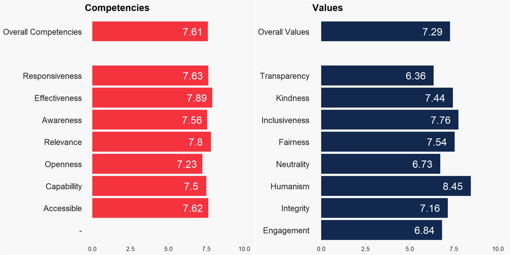

## Score per profile

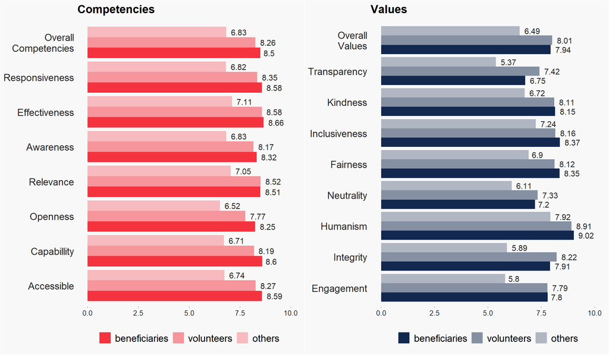

Download Summary Excel File

## Significance testing

| Dimension | Drivers | Volunteer-Other | Volunteer-Beneficiary | Benficiary-Other |
| --- | --- | --- | --- | --- |
| Competency | Capabillity | Yes | Yes | Yes |
| Competency | Responsiveness | Yes | No | Yes |
| Competency | Awareness | Yes | No | Yes |
| Competency | Accessible | Yes | No | Yes |
| Competency | Openess | Yes | No | Yes |
| Competency | Relevance | Yes | No | Yes |
| Competency | Effectiveness | Yes | No | Yes |
| Value | Kindness | Yes | No | Yes |
| Value | Fairness | Yes | No | Yes |
| Value | Inclusiveness | Yes | No | Yes |
| Value | Engagement | Yes | No | Yes |
| Value | Integrity | Yes | No | Yes |
| Value | Transparency | Yes | No | Yes |
| Value | Neutrality | Yes | No | Yes |
| Value | Humanism | Yes | No | Yes |